# Lab 4 - Multinomial Regression - Questions

Author

Suyog Chandramouli

Published

March 20, 2025

Lab Goal: Predict voting frequency using demographic variables Data source: FiveThirtyEight “Why Many Americans Don’t Vote” survey Method: Multinomial logistic regression

## Data

The data for this assignment comes from an online Ipsos survey that was conducted for the FiveThirtyEight article [“Why Many Americans Don’t Vote”](https://projects.fivethirtyeight.com/non-voters-poll-2020-election/). You can read more about the survey design and respondents in the README of the [GitHub repo](https://github.com/fivethirtyeight/data/tree/master/non-voters) for the data.

Respondents were asked a variety of questions about their political beliefs, thoughts on multiple issues, and voting behavior. We will focus on using the demographic variables and someone’s party identification to understand whether a person is a probable voter.

The variables we’ll focus on were (definitions from the codebook in data set GitHub repo):

- `ppage`: Age of respondent
- `educ`: Highest educational attainment category.
- `race`: Race of respondent, census categories. Note: all categories except Hispanic were non-Hispanic.
- `gender`: Gender of respondent
- `income_cat`: Household income category of respondent
- `Q30`: Response to the question “Generally speaking, do you think of yourself as a…”
  - 1: Republican
  - 2: Democrat
  - 3: Independent
  - 4: Another party, please specify
  - 5: No preference
  - -1: No response
- `voter_category`: past voting behavior:
  - **always**: respondent voted in all or all-but-one of the elections they were eligible in
  - **sporadic**: respondent voted in at least two, but fewer than all-but-one of the elections they were eligible in
  - **rarely/never**: respondent voted in 0 or 1 of the elections they were eligible in

You can read in the data directly from the GitHub repo:

```r
library(nnet)
library(car)
library(tidyverse)
library(emmeans)
library(ggeffects)
library(knitr)
library(patchwork)
library(broom)
library(parameters)
library(easystats)
```

```r
voter_data <- read_csv("https://raw.githubusercontent.com/fivethirtyeight/data/master/non-voters/nonvoters_data.csv")
```

# Lab

- The variable `Q30` contains the respondent’s political party identification. Make a new variable that simplifies `Q30` into four categories: “Democrat”, “Republican”, “Independent”, “Other” (“Other” also includes respondents who did not answer the question).

```r
voter_data <- voter_data %>%
  mutate(pol_ident_new = case_when(
    Q30==1 ~ "Rep",
    Q30==2 ~ "Dem",
    Q30==3 ~ "Indep",
    TRUE ~ "Other"
  ))
```

- The variable `voter_category` identifies the respondent’s past voter behavior. Relevel the variable to make rarely/never the baseline level, followed by sporadic, then always

```r
#Enter your code
voter_data$voter_category <- ordered(voter_data$voter_category, levels = c("rarely/never", "sporadic", "always"))
```

- Center the age variable to make the intercept more interepretable. That is, so that it reflects the log-odds for an average-aged person rather than a 0-year old person

```r
# enter code
voter_data$ppage <- scale(voter_data$ppage, center = TRUE, scale = FALSE)
voter_data$educ <- as.factor(voter_data$educ)
```

- In the [FiveThirtyEight article](https://projects.fivethirtyeight.com/non-voters-poll-2020-election/), the authors include visualizations of the relationship between the voter category and demographic variables such as race, age, education, etc. Select two demographic variables. For each variable, try to replicate the visualizations and interpret the plot to describe its relationship with voter category. Have fun with it: https://www.mikelee.co/posts/2020-02-08-recreate-fivethirtyeight-chicklet-stacked-bar-chart-in-ggplot2.

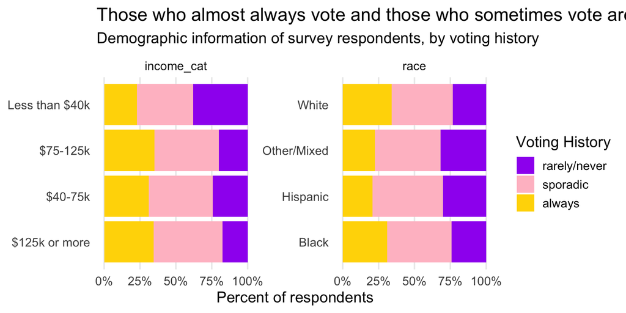

```r
# library
library(ggplot2)
library(viridis)
library(cowplot)

dem_cols <- c("race", "income_cat")

# Enter code
df_long <- voter_data %>%
  dplyr::select(race, income_cat, voter_category) %>%
  pivot_longer(
    cols      = all_of(dem_cols),
    names_to  = "demographic",    # e.g. "race", "income_cat", etc.
    values_to = "category"        # e.g. "White", "< $40K", "College", "Dem", ...
  ) %>%
  # 3) Count how many people fall into each (demographic, category, voter_category)
  group_by(demographic, category, voter_category) %>%
  summarize(n = n(), .groups = "drop") %>%
  # 4) Within each (demographic, category), get the proportion in each voter_category
  group_by(demographic, category) %>%
  mutate(prop = n / sum(n)) %>%
  ungroup()

# 5) Plot with ggplot2
ggplot(df_long, aes(x = category, y = prop, fill = voter_category)) +
  # 'geom_col(position="fill")' would re‐scale each stack to 100%,
  # but since we already computed 'prop', we can just do position="stack".
  # Either way works; let's use the actual 'prop' here with position="stack".
  geom_col(position = "stack") +

  # If you *did* want ggplot to do the proportion calculation automatically:
  # geom_col(position = "fill", aes(y = ..count..))

  # Flip coordinates for horizontal bars
  coord_flip() +

  # Facet each demographic dimension in its own small panel
  facet_wrap(~ demographic, scales = "free_y") +

  # Format y‐axis as percentages
  scale_y_continuous(labels = scales::percent_format()) +

  # Optional: manually set the fill colors to match the original chart
  scale_fill_manual(values = c("rarely/never" = "purple",
                               "sporadic"     = "pink",
                               "always"       = "gold")) +

  labs(
    x        = NULL,
    y        = "Percent of respondents",
    fill     = "Voting History",
    title    = "Those who almost always vote and those who sometimes vote aren’t that different",
    subtitle = "Demographic information of survey respondents, by voting history"
  ) +
  theme_minimal(base_size = 14) +
  theme(
    panel.grid.major.y = element_blank(),
    panel.grid.minor   = element_blank()
  )
```

- Fit a model using mean-centered age, race, gender, income, and education to predict voter category. Show the code used to fit the model, but do **not** display the model output.

```r
library(nnet)

#Enter code
mm_use <- multinom(voter_category ~ ppage + race + gender + income_cat + educ, data = voter_data)
```

- *Should party identification be added to the model?*
- #Hint: Use an anova test to make the determination

```r
#Enter code
mm_pi <- multinom(voter_category ~ ppage + race + gender + income_cat + educ + pol_ident_new, data = voter_data)
anova(mm_use, mm_pi)
```

```
                                                      Model Resid. df
1                 ppage + race + gender + income_cat + educ     11650
2 ppage + race + gender + income_cat + educ + pol_ident_new     11644
  Resid. Dev   Test    Df LR stat. Pr(Chi)
1   11386.63           NA       NA      NA
2   11232.78 1 vs 2     6  153.844       0
```

```
> #Enter answer based on your code: We'll include party identification in the model! It's residuals are significantly different from the model without it.
```

**Use the model you select for the remainder of the assignment**.

## LRT

- Run the full model and report overall significance of each of the terms

```r
kable(summary(mm_pi)$coefficients)
```

|  | (Intercept) | ppage | raceHispanic | raceOther/Mixed | raceWhite | genderMale | income_cat$40-75k | income_cat$75-125k | income_catLess than $40k | educHigh school or less | educSome college | pol_ident_newIndep | pol_ident_newOther | pol_ident_newRep |
| --- | --- | --- | --- | --- | --- | --- | --- | --- | --- | --- | --- | --- | --- | --- |
| sporadic | 1.731560 | 0.0456862 | 0.0402386 | -0.3324253 | -0.0775381 | -0.0900590 | -0.0737542 | 0.0124992 | -0.5878096 | -0.8532927 | -0.2928893 | -0.3924293 | -0.940448 | -0.0838051 |
| always | 1.490383 | 0.0582075 | -0.3410192 | -0.6004751 | 0.1272075 | -0.1921892 | -0.0003682 | 0.1651971 | -0.6640936 | -1.2672114 | -0.3303234 | -0.5623037 | -1.400990 | -0.1617677 |

```r
    library(nnet)

# Suppose your model is:
# mm_pi <- multinom(voter_category ~ ppage + race + ..., data = mydata)

# 1. Extract coefficient and standard-error matrices
coefs <- summary(mm_pi)$coefficients        # matrix with rows=outcomes, cols=predictors
ses   <- summary(mm_pi)$standard.errors     # matching matrix of standard errors

# 2. Compute z-scores
z_vals <- coefs / ses

# 3. Convert to p-values (two-sided, normal approx)
p_vals <- 2 * (1 - pnorm(abs(z_vals)))

# 4. Put p-values in a data frame
pvals_df <- as.data.frame(p_vals)

# Give it nice row/column names
rownames(pvals_df) <- rownames(coefs)       # outcome categories (e.g. "sporadic", "always")
colnames(pvals_df) <- colnames(coefs)       # variable names (e.g. "(Intercept)", "ppage", ...)

# Now 'pvals_df' holds just the p-values
kable(pvals_df)
```

|  | (Intercept) | ppage | raceHispanic | raceOther/Mixed | raceWhite | genderMale | income_cat$40-75k | income_cat$75-125k | income_catLess than $40k | educHigh school or less | educSome college | pol_ident_newIndep | pol_ident_newOther | pol_ident_newRep |
| --- | --- | --- | --- | --- | --- | --- | --- | --- | --- | --- | --- | --- | --- | --- |
| sporadic | 0 | 0 | 0.7532558 | 0.0366240 | 0.4721734 | 0.2120873 | 0.5077964 | 0.9066818 | 2e-07 | 0 | 0.0020947 | 5.9e-05 | 0 | 0.4147957 |
| always | 0 | 0 | 0.0227669 | 0.0011992 | 0.2841856 | 0.0158390 | 0.9975757 | 0.1482911 | 2e-07 | 0 | 0.0012572 | 1.0e-07 | 0 | 0.1419129 |

[output not shown]

[output not shown]

## Marginal Effects of Education - Emmeans

```r
#using
multinomial_analysis <- emmeans(mm_pi, ~educ|voter_category)


coefs_ed = contrast(regrid(multinomial_analysis, "log"),"trt.vs.ctrl1",  by="educ")
# you can add a parameter to the above command, ref = newbaseline, if you want to change baseline

update(coefs_ed, by = "contrast") %>%
 kable(format = "markdown", digits = 3)
```

| contrast | educ | estimate | SE | df | t.ratio | p.value |
| --- | --- | --- | --- | --- | --- | --- |
| sporadic - (rarely/never) | College | 0.986 | 0.076 | 28 | 12.904 | 0.000 |
| always - (rarely/never) | College | 0.477 | 0.080 | 28 | 5.960 | 0.000 |
| sporadic - (rarely/never) | High school or less | 0.187 | 0.069 | 28 | 2.705 | 0.031 |
| always - (rarely/never) | High school or less | -0.711 | 0.080 | 28 | -8.883 | 0.000 |
| sporadic - (rarely/never) | Some college | 0.707 | 0.074 | 28 | 9.512 | 0.000 |
| always - (rarely/never) | Some college | 0.167 | 0.079 | 28 | 2.114 | 0.112 |

- Next, plot the predicted probabilities of voter category as a function of Age and Party ID

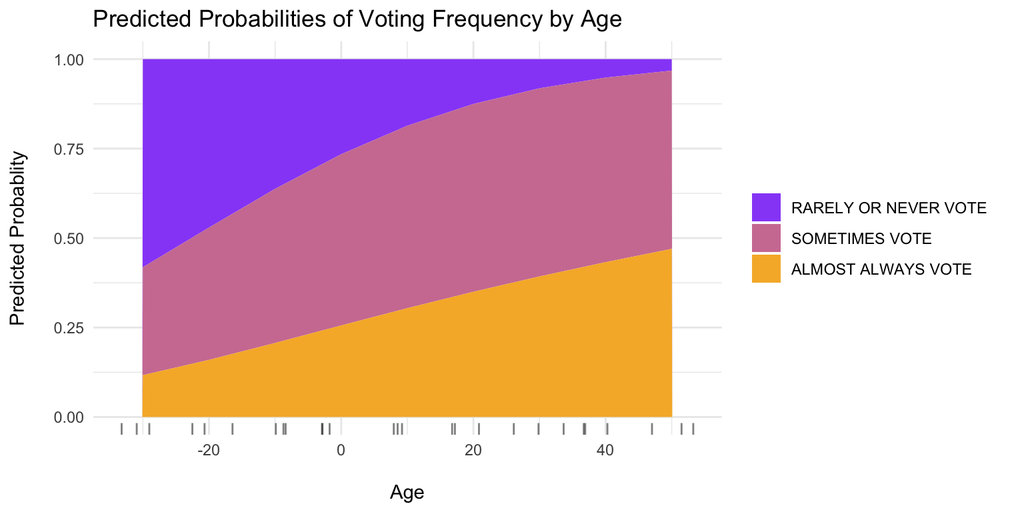

```r
  ggemmeans(mm_pi, terms = c("ppage")) %>%
      ggplot(., aes(x = x, y = predicted, fill = response.level)) +
      geom_area() +
      geom_rug(sides = "b", position = "jitter", alpha = .5) +
      labs(x = "\nAge", y = "Predicted Probablity\n", title = "Predicted Probabilities of Voting Frequency by Age") +
      scale_fill_manual(
        name = NULL,
        values = c("always" = "#F6B533", "sporadic" = "#D07EA2", "rarely/never" = "#9854F7"),
        labels = c("RARELY OR NEVER VOTE    ", "SOMETIMES VOTE    ", "ALMOST ALWAYS VOTE    "),
        breaks = c("rarely/never", "sporadic", "always")
      ) +
      theme_minimal()
```

Plot predicted probabilities as a function of education and voting frequency.

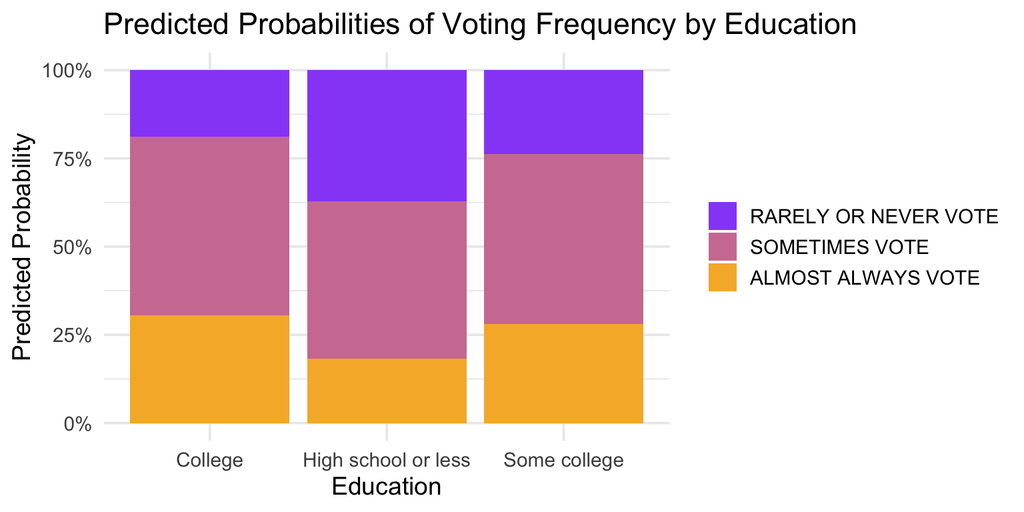

```r
# 1) Generate predicted values for all levels of 'educ'
pred_data <- ggemmeans(mm_pi, terms = "educ")

# 2) Plot as a stacked bar chart
ggplot(pred_data, aes(x = x, y = predicted, fill = response.level)) +
  geom_col(position = "stack") +

  # X-axis becomes the 3 distinct education levels
  scale_x_discrete(name = "Education") +
  scale_y_continuous(name = "Predicted Probability", labels = scales::percent_format()) +

  # Optional: custom fill colors & legend labels
  scale_fill_manual(
    name   = NULL,
    values = c("always" = "#F6B533",
               "sporadic" = "#D07EA2",
               "rarely/never" = "#9854F7"),
    labels = c("rarely/never" = "RARELY OR NEVER VOTE",
               "sporadic"     = "SOMETIMES VOTE",
               "always"       = "ALMOST ALWAYS VOTE")
  ) +

  # Title, etc.
  labs(
    title = "Predicted Probabilities of Voting Frequency by Education"
  ) +
  theme_minimal(base_size = 14)
```

[output not shown]

### Differences between political groups and voting behavior - Emmeans

```r
multi_an <- emmeans(mm_pi, ~ pol_ident_new|voter_category)

coefs = contrast(regrid(multi_an, "log"),"trt.vs.ctrl1",  by="pol_ident_new")

update(coefs, by = "contrast") %>%
  kable(format = "markdown", digits = 3)
```

| contrast | pol_ident_new | estimate | SE | df | t.ratio | p.value |
| --- | --- | --- | --- | --- | --- | --- |
| sporadic - (rarely/never) | Dem | 0.961 | 0.070 | 28 | 13.722 | 0.000 |
| always - (rarely/never) | Dem | 0.480 | 0.074 | 28 | 6.498 | 0.000 |
| sporadic - (rarely/never) | Indep | 0.591 | 0.077 | 28 | 7.643 | 0.000 |
| always - (rarely/never) | Indep | -0.049 | 0.084 | 28 | -0.590 | 0.900 |
| sporadic - (rarely/never) | Other | 0.078 | 0.087 | 28 | 0.902 | 0.747 |
| always - (rarely/never) | Other | -0.835 | 0.110 | 28 | -7.577 | 0.000 |
| sporadic - (rarely/never) | Rep | 0.883 | 0.084 | 28 | 10.469 | 0.000 |
| always - (rarely/never) | Rep | 0.327 | 0.089 | 28 | 3.672 | 0.004 |

```r
# get difference between yes-no and fair-excellent
contrast(coefs, "revpairwise", by = "contrast") %>%
  kable(format = "markdown", digits = 3)
```

| contrast1 | contrast | estimate | SE | df | t.ratio | p.value |
| --- | --- | --- | --- | --- | --- | --- |
| Indep - Dem | sporadic - (rarely/never) | -0.370 | 0.094 | 28 | -3.933 | 0.003 |
| Other - Dem | sporadic - (rarely/never) | -0.883 | 0.103 | 28 | -8.578 | 0.000 |
| Other - Indep | sporadic - (rarely/never) | -0.513 | 0.107 | 28 | -4.807 | 0.000 |
| Rep - Dem | sporadic - (rarely/never) | -0.078 | 0.099 | 28 | -0.787 | 0.860 |
| Rep - Indep | sporadic - (rarely/never) | 0.292 | 0.099 | 28 | 2.965 | 0.029 |
| Rep - Other | sporadic - (rarely/never) | 0.805 | 0.109 | 28 | 7.404 | 0.000 |
| Indep - Dem | always - (rarely/never) | -0.529 | 0.101 | 28 | -5.255 | 0.000 |
| Other - Dem | always - (rarely/never) | -1.315 | 0.125 | 28 | -10.508 | 0.000 |
| Other - Indep | always - (rarely/never) | -0.786 | 0.129 | 28 | -6.072 | 0.000 |
| Rep - Dem | always - (rarely/never) | -0.153 | 0.104 | 28 | -1.470 | 0.468 |
| Rep - Indep | always - (rarely/never) | 0.376 | 0.104 | 28 | 3.605 | 0.006 |
| Rep - Other | always - (rarely/never) | 1.162 | 0.130 | 28 | 8.969 | 0.000 |

### Differences between education level and voting behavior - Emmeans

Last part of the assignment: Interpret the results from running the following code for your model

```r
multi_an <- emmeans(mm_pi, ~ educ|voter_category)

coefs = contrast(regrid(multi_an, "log"),"trt.vs.ctrl1",  by="educ")

update(coefs, by = "contrast") %>%
  kable(format = "markdown", digits = 3)
```

| contrast | educ | estimate | SE | df | t.ratio | p.value |
| --- | --- | --- | --- | --- | --- | --- |
| sporadic - (rarely/never) | College | 0.986 | 0.076 | 28 | 12.904 | 0.000 |
| always - (rarely/never) | College | 0.477 | 0.080 | 28 | 5.960 | 0.000 |
| sporadic - (rarely/never) | High school or less | 0.187 | 0.069 | 28 | 2.705 | 0.031 |
| always - (rarely/never) | High school or less | -0.711 | 0.080 | 28 | -8.883 | 0.000 |
| sporadic - (rarely/never) | Some college | 0.707 | 0.074 | 28 | 9.512 | 0.000 |
| always - (rarely/never) | Some college | 0.167 | 0.079 | 28 | 2.114 | 0.112 |

```r
# get difference between yes-no and fair-excellent
contrast(coefs, "revpairwise", by = "contrast") %>%
  kable(format = "markdown", digits = 3)
```

| contrast1 | contrast | estimate | SE | df | t.ratio | p.value |
| --- | --- | --- | --- | --- | --- | --- |
| High school or less - College | sporadic - (rarely/never) | -0.799 | 0.095 | 28 | -8.416 | 0.000 |
| Some college - College | sporadic - (rarely/never) | -0.278 | 0.092 | 28 | -3.030 | 0.014 |
| Some college - High school or less | sporadic - (rarely/never) | 0.520 | 0.088 | 28 | 5.920 | 0.000 |
| High school or less - College | always - (rarely/never) | -1.188 | 0.104 | 28 | -11.394 | 0.000 |
| Some college - College | always - (rarely/never) | -0.310 | 0.097 | 28 | -3.207 | 0.009 |
| Some college - High school or less | always - (rarely/never) | 0.878 | 0.098 | 28 | 8.995 | 0.000 |

Enter your interpretation here: It seems like college‐educated respondents generally show higher probabilities of voting “sporadic” or “always” (compared to “rarely/never”) than those with less education. The difference is most pronounced for those with a college education, who are more likely to vote “always” than those with less education.